# Do Mothers Influence Primate Culture?

Analyzing a possible correlation between cultural intelligence and motherhood

Thomas Wilson  
4/06/2022

INTRODUCTION

Over the past few decades, researchers have highlighted just how similar humans are to our closest living relatives - primates. We used to think that humans possessed several unique achievements that separated us from the rest of the primates. Achievements such as tool use, language, and social learning; however, we now have evidence of each of those achievements in several primate species (Fragaszy et al, 2013). Today, there is still a heavy debate among primatologists and evolutionary biologist about culture - not over the definition of culture, but rather is culture unique to humans or does the rest of the Order Primates exhibit culture as well. Culture can be summarized as “the attitudes and behavior characteristic of a particular social group”. More importantly, culture is also associated with the idea that these behaviors are passed down and social taught between generations. This assumption that culture is “inherited” between generations suggest that life-history traits such as life expectancy and inter-birth intervals may play a significant role in culture remaining within isolated social groups. To suggest that humans are the only animal capable of having culture seems a bit naive, therefore the goal of this project is not only to argue for the presence of culture throughout the Order Primates, but also to highlight a possible correlation between culture and life-history traits that are directly related to mothers (i.e age of mother at birth, inter-birth rate, and number of offspring produced).

To help shed some light onto primate culture, I’ll be using two different public datasets. The first data set “The evolution of primate general and cultural intelligence” is a dataset that complied recorded observations of behaviors related to primate “intelligence” (Reader et al, 2011). The data consists of variables include the number of recorded observations of the following behavior;innovation, tool use, extractive foraging, and social learning. The observations are grouped by primate species and further divided into two groups - great apes and the rest. Information is also included on the number of journal searches per primate species.

The second dataset, “Female reproductive aging in seven primate species: patterns and consequences”, is included to provide data on mother related life-history traits (Campos et al, 2021). The data used was meant to analyze analyze age-related risks in female reproductive performance of seven primate populations. The variables include primate genus, ID of the female infants, the age of mother at birth, the time that new infants are at risk, the mother ID, the number of births each mother has had, and which population infants were born into.

*Datasets*

```r
Data_ReaderHagerLalandPhilTrans2011 <- read_csv("Data_ReaderHagerLalandPhilTrans2011.csv")
View(Data_ReaderHagerLalandPhilTrans2011)
Primate_ToolUse <- Data_ReaderHagerLalandPhilTrans2011

#Removed columns that weren't useful to potential research questions
Primate_ToolUse <- Primate_ToolUse[-c(3,4,11:13,15:20)]
view(Primate_ToolUse)

FemalePrimate_Reproduction <- read_csv("03_afr.csv")
view(FemalePrimate_Reproduction)
```

1. Does a mother’s age affect recorded levels of cultural intelligence?

2.Does the age of mothers/general life history traits affect the frequency of tool use?

3. Does the number of offspring a female has influence cultural intelligence?

4. If journal searches indicate a bias in primate research, then are the number of observations of foraging behaviors (tool use, social learning, innovation, extractive foraging) skewed because more research is done on particular genera/species?

ANALYSIS

The primate species used in the two datasets are very similar; however, the cultural intelligence data refers to specific species and the motherhood data refers to individuals only by the genus. So here is a key to help make inferences and conclusions between the two types of data:

[Genus::Common Name] Cebus::Capuchin, Propithecus::Sifaka, Brachyteles::Muriqui, Cercopithecus::Blue Monkey, Papio::Baboon, Pan::Chimpanzee, Gorilla::Gorilla

*Data Manipulation and Graphing*

The mean of cultural behaviors (tool use, social learning, innovation, extractive foraging)

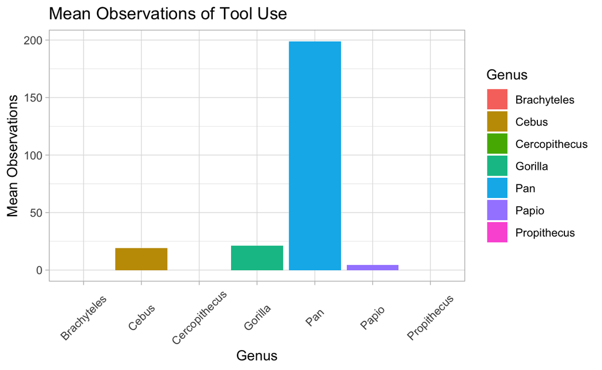

```r
ToolUse_Means_Genus <- Primate_ToolUse %>%
  group_by(`Genus`) %>%
  filter(grepl('Cebus|Propithecus|Brachy|Cercop|Papio|Pan|Gorilla', Genus)) %>%
  summarise(Tool_Use = mean(`Tool use`))

ggplot(ToolUse_Means_Genus, aes(x= `Genus`, y= `Tool_Use`, fill= `Genus`)) +
  geom_bar(stat = "Identity") +
  labs(title = "Mean Observations of Tool Use", y = "Mean Observations", x = "Genus") +
  theme_light() +
  theme(axis.text.x = element_text(angle = 45, vjust = 0.5))
```

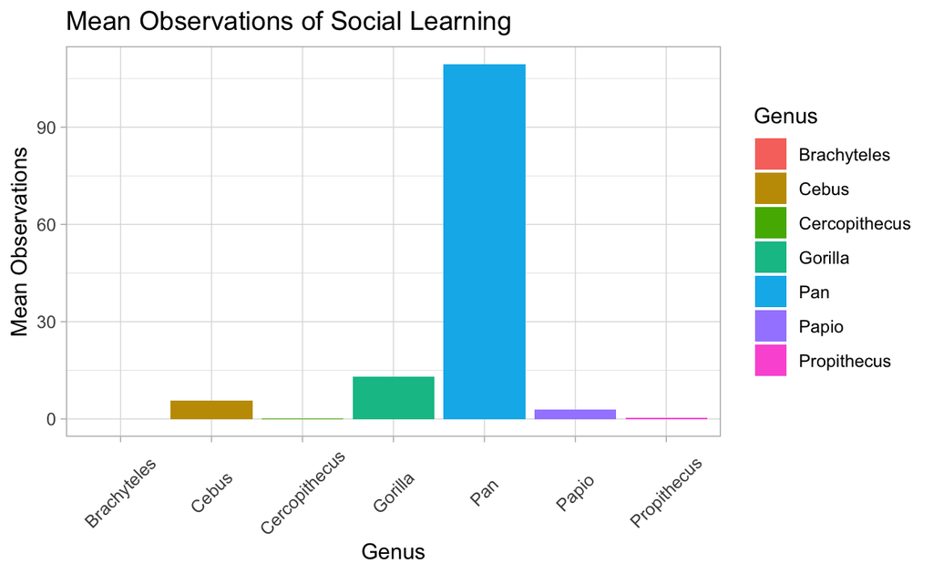

```r
SocialLearning_Means_Genus <- Primate_ToolUse %>%
  group_by(`Genus`) %>%
  filter(grepl('Cebus|Propithecus|Brachy|Cercop|Papio|Pan|Gorilla', Genus)) %>%
  summarise(Social_Learning = mean(`Social learning`))

ggplot(SocialLearning_Means_Genus, aes(x= `Genus`, y= `Social_Learning`, fill= `Genus`)) +
  geom_bar(stat = "Identity") +
  labs(title = "Mean Observations of Social Learning", y = "Mean Observations", x = "Genus") +
  theme_light() +
  theme(axis.text.x = element_text(angle = 45, vjust = 0.5))
```

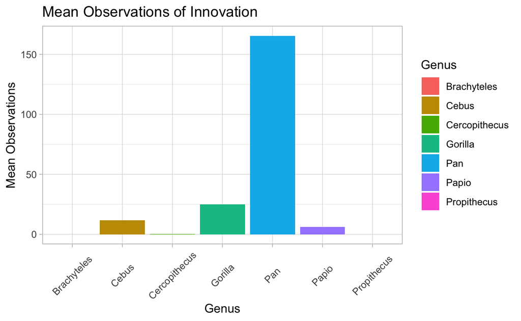

```r
Innovation_Means_Genus <- Primate_ToolUse %>%
  group_by(`Genus`) %>%
  filter(grepl('Cebus|Propithecus|Brachy|Cercop|Papio|Pan|Gorilla', Genus)) %>%
  summarise(Innovation = mean(Innovation))

ggplot(Innovation_Means_Genus, aes(x= `Genus`, y= `Innovation`, fill= `Genus`)) +
  geom_bar(stat = "Identity") +
  labs(title = "Mean Observations of Innovation", y = "Mean Observations", x = "Genus") +
  theme_light() +
  theme(axis.text.x = element_text(angle = 45, vjust = 0.5))
```

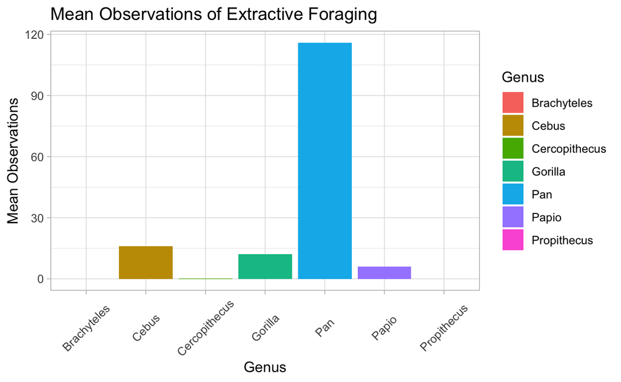

```r
Foraging_Means_Genus <- Primate_ToolUse %>%
  group_by(`Genus`) %>%
  filter(grepl('Cebus|Propithecus|Brachy|Cercop|Papio|Pan|Gorilla', Genus)) %>%
  summarise(Foraging = mean(`Extractive foraging`))

ggplot(Foraging_Means_Genus, aes(x= `Genus`, y= `Foraging`, fill= `Genus`)) +
  geom_bar(stat = "Identity") +
  labs(title = "Mean Observations of Extractive Foraging", y = "Mean Observations", x = "Genus") +
  theme_light() +
  theme(axis.text.x = element_text(angle = 45, vjust = 0.5))
```

How many mothers have had more than one offspring (Multiparous) or was it the mother’s first offspring (Primiparous).

Graphing mean mother age for each of the species, as well all mothers’ ages per species

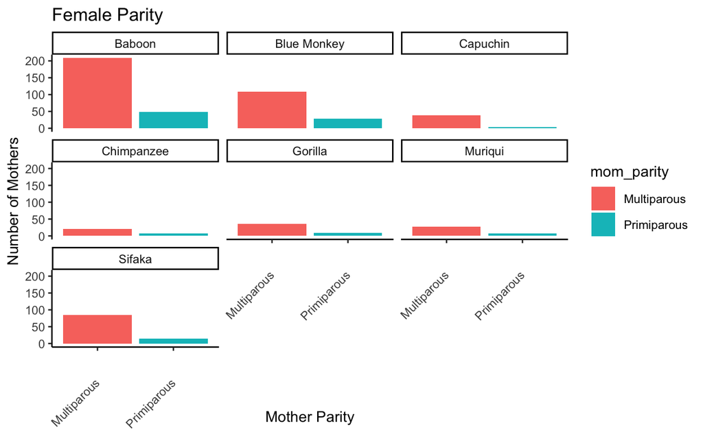

```r
FemalePrimate_Reproduction <- read_csv("03_afr.csv")
view(FemalePrimate_Reproduction)

FemalePrimate_Reproduction %>%
  ggplot(aes(x=`mom_parity`, fill= mom_parity)) +
  geom_bar() +
  labs(title = "Female Parity", y = "Number of Mothers", x = "Mother Parity") +
  theme_classic(base_size = 10) +
  theme(axis.text.x = element_text(angle = 45, vjust = 0.5, hjust=1)) +
  facet_wrap(vars(species))
```

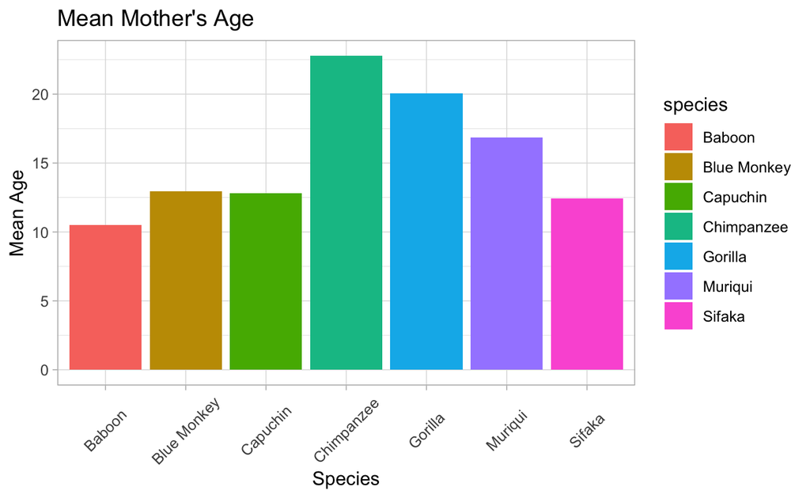

```r
Mean_Mothers_Age <- FemalePrimate_Reproduction %>%
  group_by(`species`) %>%
  summarise(Mother_Age = mean(mom_age_years))

ggplot(Mean_Mothers_Age, aes(x= `species`, y= `Mother_Age`, fill= `species`)) +
  geom_bar(stat = "Identity") +
  labs(title = "Mean Mother's Age", y = "Mean Age", x = "Species") +
  theme_light() +
  theme(axis.text.x = element_text(angle = 45, vjust = 0.5))
```

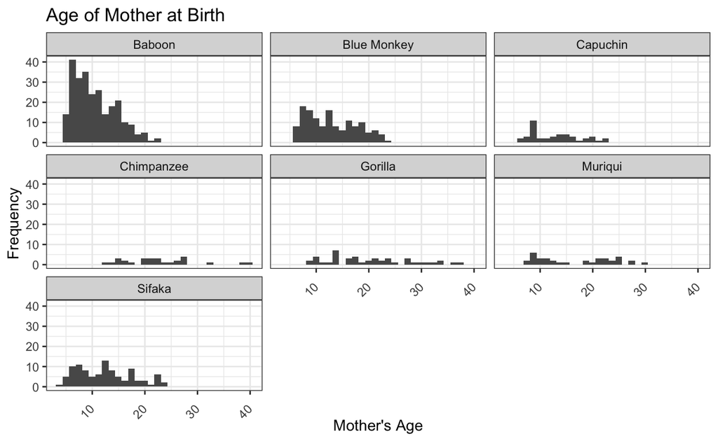

```r
FemalePrimate_Reproduction %>%
  group_by(species) %>%
 ggplot(aes(x=`mom_age_years`)) +
  geom_histogram() +
  labs(title = "Age of Mother at Birth", x = "Mother's Age", y= "Frequency") +
  theme_bw(base_size = 10) +
  theme(axis.text.x = element_text(angle = 45, vjust = 0.5, hjust=1)) +
  facet_wrap(vars(species))
```

Highest count in journal searches per genus of interest

```r
Primate_ToolUse %>%
  group_by(`Genus`) %>%
  filter(grepl('Cebus|Propithecus|Brachy|Cercop|Papio|Pan|Gorilla', Genus)) %>%
  summarise(max(`Journal Search Article Count`, na.rm = TRUE))
```

```
# A tibble: 7 x 2
  Genus         `max(\`Journal Search Article Count\`, na.rm = TRUE)`
  <chr>                                                         <dbl>
1 Brachyteles                                                      15
2 Cebus                                                           111
3 Cercopithecus                                                    17
4 Gorilla                                                         112
5 Pan                                                             364
6 Papio                                                            41
7 Propithecus                                                      13
```

RESULTS/DISCUSSION

When looking at motherhood, the data reveals the baboons not only have the highest count of young mothers, but they also tend to have more than one offspring compared to the other six species. Furthermore, chimpanzees seemed to have the highest mean age of mother’s at birth. Lastly, when looking at journal searches, chimpanzees had the highest (364) which is more than twice the second and third highest, gorillas (112) and capuchins (cebus) (111).

These results suggests potential influences between social behaviors and motherhood within primates. Female chimpanzees seem to have children at an older age than all other species included on this study, which suggest that older mothers have influence on social behavior. Chimpanzees had the highest mean observation for each type of social behavior. However, it would be very naive to consider mother’s age as the only factor. For example, cranial capacity could have a huge role in social behavior as well as life expectancy - both are which the highest in chimpanzees (Herndon et al, 1999). Furthermore, it seems that the species with the lowest observations of cultural behaviors (sifaka, muriqui, and blue monkeys) do not exhibit the youngest mothers. Moreover, there seem to be no recognizable pattern between frequent tool use and the number of children a female has over life. However, these numbers may be skewed due to sampling methodology seeing as some females were counted twice, once as primiparous and then again after the next birth. Lastly, it does seem to be bias within journal searches, chimpanzees have by far the greatest number of journal searches which may be an indicator of pure bias for chimpanzees, which would then produce higher observations of cultural behaviors. Furthermore, the three species that were searched the least also exhibit the lowest means for each cultural behavior.

Moving forward, to continue to investigate the possible relationship between motherhood and culture, researchers should further investigate mother-infant interaction, as well as other factors such as age of independence of offspring and other life history traits. Furthermore, to eliminate the bias seen within primatology and to better investigate this possible relationship, researchers should collect data on cultural behaviors at an equal opportunity rather than using previous recorded data. These edits and suggestions outline a better project that might reveal a correlation between culture and motherhood.

*REFERENCES*

Campos, F., Altmann, J., Cords, M., Fedigan, L., Lawler, R., Lonsdorf, E., Stoinski, T., Strier, K., Bronikowski, A., Pusey, A., & Alberts, S. (2021). Data from: Female reproductive aging in seven primate species: patterns and consequences. Duke Research Data Repository.

Fragaszy, D. M., Biro, D., Eshchar, Y., Humle, T., Izar, P., Resende, B., & Visalberghi, E. (2013). The fourth dimension of tool use: temporally enduring artefacts aid primates learning to use tools. Philosophical Transactions of the Royal Society B: Biological Sciences, 368(1630), 20120410.

Herndon, J. G., Tigges, J., Anderson, D. C., Klumpp, S. A., & McClure, H. M. (1999). Brain weight throughout the life span of the chimpanzee. Journal of Comparative Neurology, 409(4), 567-572.

Reader SM, Hager Y & Laland KN. (2011). The evolution of primate general and cultural intelligence. Philosophical Transactions of the Royal Society B, 366:1017-1027